# [Kobe Bryant Shot Selection](https://www.kaggle.com/c/kobe-bryant-shot-selection)

[Emerson Rigoni](http://lattes.cnpq.br/9410653573760282) Henrique Aparecido Laureano [[Lattes](http://lattes.cnpq.br/2224901552085090), [GitHub](https://github.com/mynameislaure)]

Julho de 2016

[figure not shown]

> A temporada 2015/2016 foi a vigésima e última temporada de Kobe Bryant como jogador da  
> NBA. A base de dados aqui analisada contabiliza todos os 30697 arremessos tentados por Kobe nessas 20 temporadas

> Destes, não sabemos se 5000 mil (16%) arremessos foram convertidos

> A proposta é, a partir dos 25697 arremessos que sabemos o resultado - conversão ou não - utilizar diferentes metodologias para fazer a predição desse desfecho

**Para auxiliar nessa tarefa algumas covariáveis foram disponibilizadas, na próxima seção algumas delas são apresentadas**

# Conhecendo os dados

```r
library(latticeExtra)
```

> A imensa maioria dos arremessos tentados por Kobe foram do tipo *jump shot*

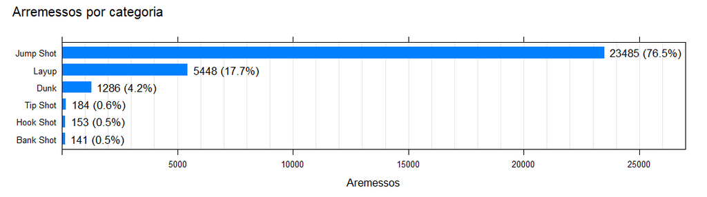

```r
barchart(sort(table(kobe$combined_shot_type))
         , col = "#0080ff"
         , border = "transparent"
         , xlim = c(0, 27000)
         , xlab = "Aremessos"
         , main = "Arremessos por categoria"
         , par.settings = settings
         , panel = function(...){
           panel.abline(v = seq(0, 26000, 1000), col = "gray90")
           args <- list(...)
           panel.text(
             args$x, args$y, paste0(args$x, " (", round(prop.table(args$x), 3)*100, "%)")
             , pos = 4)
           panel.barchart(...)})
```

Ali os tipos de arremesso foram reunidos em maiores categorias, mas temos uma informação mais detalhada dos tipos de arremessos tentados

```r
table(kobe$action_type)
```

```
               Alley Oop Dunk Shot               Alley Oop Layup shot
                               122                                 80
    Cutting Finger Roll Layup Shot                 Cutting Layup Shot
                                 1                                  6
                 Driving Bank shot                  Driving Dunk Shot
                                 5                                310
    Driving Finger Roll Layup Shot           Driving Finger Roll Shot
                                69                                 82
   Driving Floating Bank Jump Shot         Driving Floating Jump Shot
                                 1                                  5
                 Driving Hook Shot                  Driving Jump shot
                                14                                 28
                Driving Layup Shot         Driving Reverse Layup Shot
                              1978                                 97
            Driving Slam Dunk Shot                          Dunk Shot
                                48                                262
                Fadeaway Bank shot                 Fadeaway Jump Shot
                                31                               1048
            Finger Roll Layup Shot                   Finger Roll Shot
                                33                                 28
                Floating Jump shot                Follow Up Dunk Shot
                               114                                 15
                    Hook Bank Shot                          Hook Shot
                                 5                                 84
                    Jump Bank Shot                     Jump Hook Shot
                               333                                 24
                         Jump Shot                         Layup Shot
                             18880                               2567
                  Pullup Bank shot                   Pullup Jump shot
                                12                                476
                 Putback Dunk Shot                 Putback Layup Shot
                                 5                                 15
            Putback Slam Dunk Shot                  Reverse Dunk Shot
                                 2                                 75
                Reverse Layup Shot             Reverse Slam Dunk Shot
                               395                                 16
                 Running Bank shot                  Running Dunk Shot
                                48                                 19
    Running Finger Roll Layup Shot           Running Finger Roll Shot
                                 6                                  4
                 Running Hook Shot                  Running Jump Shot
                                41                                926
                Running Layup Shot          Running Pull-Up Jump Shot
                                72                                  4
        Running Reverse Layup Shot             Running Slam Dunk Shot
                                11                                  1
                  Running Tip Shot                     Slam Dunk Shot
                                 2                                411
               Step Back Jump shot                     Tip Layup Shot
                               118                                  2
                          Tip Shot               Turnaround Bank shot
                               182                                 71
Turnaround Fadeaway Bank Jump Shot           Turnaround Fadeaway shot
                                 1                                439
       Turnaround Finger Roll Shot               Turnaround Hook Shot
                                 2                                 14
              Turnaround Jump Shot
                              1057
```

Olhando para esse desmembramento a diferença de *jump shots* para os demais tipos de arremesso tentados se torna ainda mais evidente

> 26198 (85%) dos arremessos tentados por Kobe foram em temporadas regulares

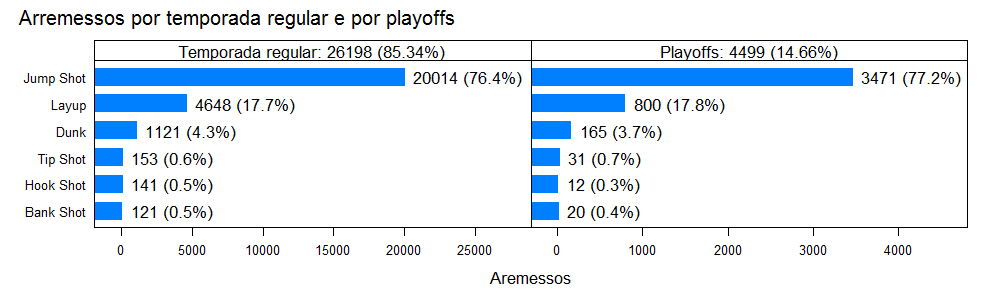

```r
devel1 <- as.data.frame(xtabs(~ playoffs + combined_shot_type, kobe))

devel1$combined_shot_type <- factor(
  devel1$combined_shot_type, levels(devel1$combined_shot_type)[c(1, 3, 6, 2, 5, 4)])

levels(devel1$playoffs) <- c("Temporada regular", "Playoffs")

levels(devel1$playoffs) <-
  paste0(levels(devel1$playoffs), ": "
         , table(kobe$playoffs), " (", round(prop.table(table(kobe$playoffs)), 4)*100, "%)")

barchart(combined_shot_type ~ Freq | playoffs
         , col = "#0080ff"
         , border = "transparent"
         , scales = list(x = "free")
         , xlim = list(c(0, 27000), c(0, 4500))
         , strip = strip.custom(bg = "white")
         , xlab = "Aremessos"
         , main = "Arremessos por temporada regular e por playoffs"
         , par.settings = settings
         , devel1
         , panel = function(...){
           args <- list(...)
           panel.text(
             args$x, args$y, paste0(args$x, " (", round(prop.table(args$x), 3)*100, "%)")
             , pos = 4)
           panel.barchart(...)})
```

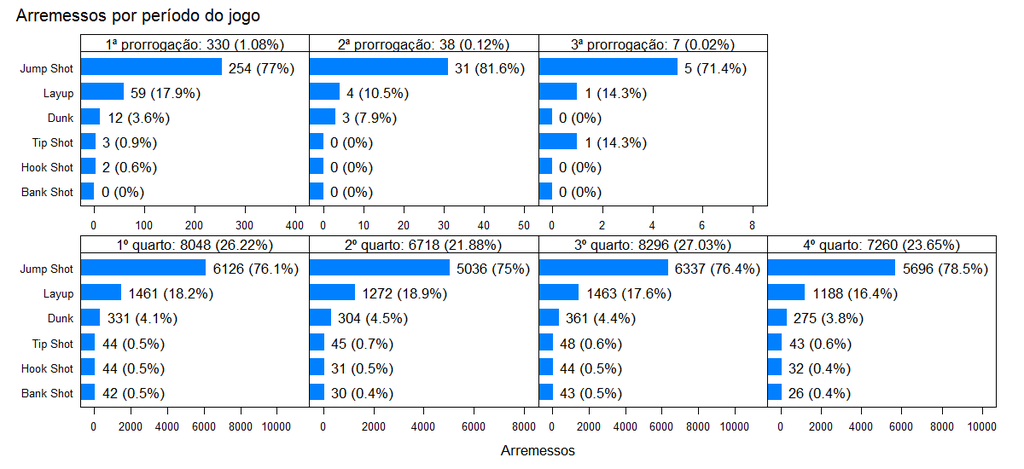

```r
devel2 <- as.data.frame(xtabs(~ period + combined_shot_type, kobe))

devel2$combined_shot_type <- factor(
  devel2$combined_shot_type, levels(devel2$combined_shot_type)[c(1, 3, 6, 2, 5, 4)])

levels(devel2$period) <- c("1º quarto", "2º quarto", "3º quarto", "4º quarto"
                           , "1ª prorrogação", "2ª prorrogação", "3ª prorrogação")

levels(devel2$period) <-
  paste0(levels(devel2$period), ": "
         , table(kobe$period), " (", round(prop.table(table(kobe$period)), 4)*100, "%)")

barchart(combined_shot_type ~ Freq | period
         , scales = list(x = "free")
         , strip = strip.custom(bg = "white")
         , xlab = "Arremessos"
         , main = "Arremessos por período do jogo"
         , par.settings = settings
         , col = "#0080ff"
         , border = "transparent"
         , xlim = list(
           c(0, 11000), c(0, 8000), c(0, 11000), c(0, 10000), c(0, 400), c(0, 50), c(0, 8))
         , layout = c(4, 2)
         , devel2
         , panel = function(...){
           args <- list(...)
           panel.text(
             args$x, args$y, paste0(args$x, " (", round(prop.table(args$x), 3)*100, "%)")
             , pos = 4)
           panel.barchart(...)})
```

> As temporadas 2002/2003, 2005/2006, 2007/2008 e 2008/2009 foram as temporadas com os maiores números de arremesso tentados por Kobe

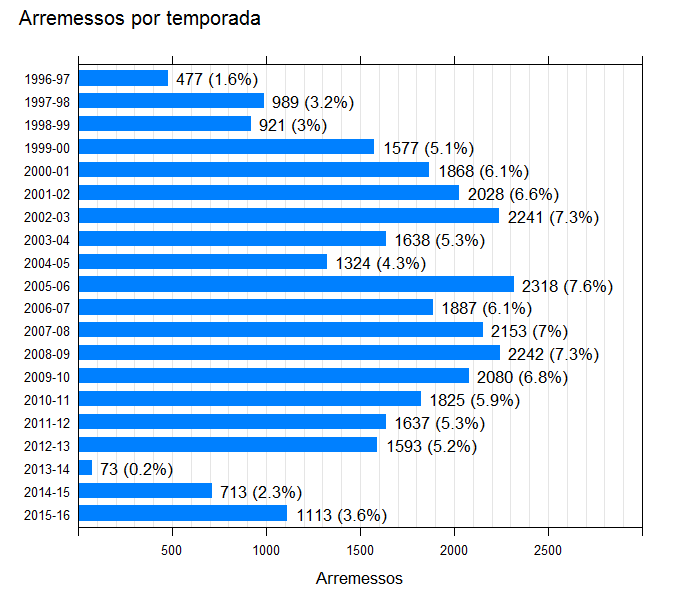

```r
devel3 <- kobe

devel3$season <- factor(devel3$season, levels(devel3$season)[20:1])

barchart(devel3$season
         , col = "#0080ff"
         , border = "transparent"
         , xlim = c(0, 3000)
         , xlab = "Arremessos"
         , main = "Arremessos por temporada"
         , par.settings = settings
         , panel = function(...){
           panel.abline(v = seq(0, 3000, 100), col = "gray90")
           args <- list(...)
           panel.text(
             args$x, args$y, paste0(args$x, " (", round(prop.table(args$x), 3)*100, "%)")
             , pos = 4)
           panel.barchart(...)})
```

> Dispersão dos arremessos

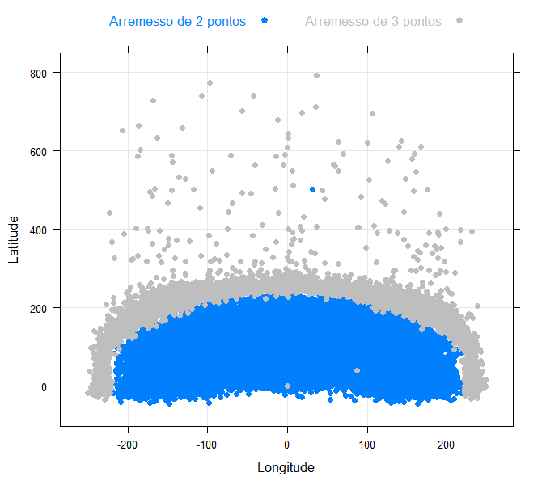

```r
xyplot(loc_y ~ loc_x, groups = shot_type
       , type = c("p", "g")
       , pch = 19
       , col = c("#0080ff", "gray")
       , xlab = "Longitude"
       , ylab = "Latitude"
       , key = list(text = list(c("Arremesso de 2 pontos", "Arremesso de 3 pontos"))
                    , points = TRUE
                    , col = c("#0080ff", "gray") , pch = 19, columns = 2)
       , kobe)
```

> Dispersão dos arremessos pela área e zona da quadra e pela distância à cesta

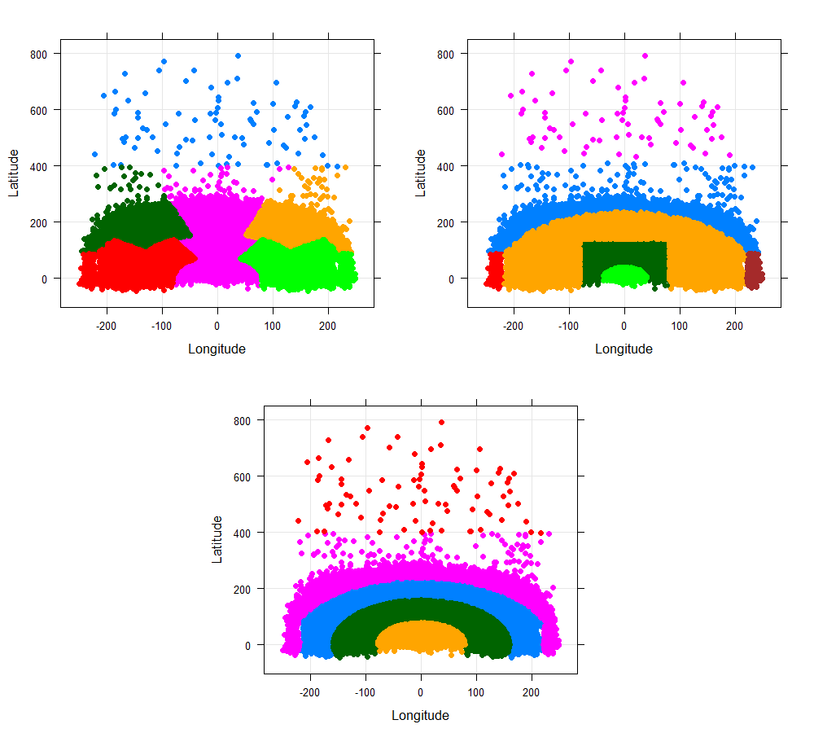

```r
print(xyplot(loc_y ~ loc_x, groups = shot_zone_area
             , type = c("p", "g")
             , pch = 19
             , xlab = "Longitude"
             , ylab = "Latitude"
             , kobe)
      , position = c(0, .5, .5, 1)
      , more = TRUE)

print(xyplot(loc_y ~ loc_x, groups = shot_zone_basic
             , type = c("p", "g")
             , pch = 19
             , xlab = "Longitude"
             , ylab = "Latitude"
             , kobe)
      , position = c(.5, .5, 1, 1)
      , more = TRUE)

print(xyplot(loc_y ~ loc_x, groups = shot_zone_range
       , type = c("p", "g")
       , pch = 19
       , xlab = "Longitude"
       , ylab = "Latitude"
       , kobe)
      , position = c(.25, 0, .75, .5))
```

> Times da conferência oeste são os adversários contra os quais Kobe tentou mais arremessos

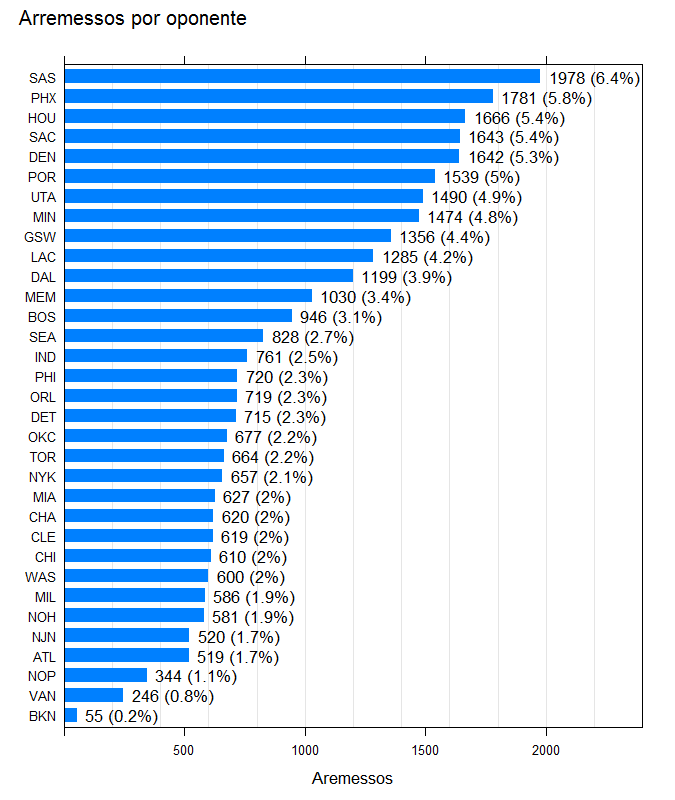

```r
barchart(sort(table(kobe$opponent))
         , col = "#0080ff"
         , border = "transparent"
         , xlim = c(0, 2400)
         , xlab = "Aremessos"
         , main = "Arremessos por oponente"
         , par.settings = settings
         , panel = function(...){
           panel.abline(v = seq(0, 2400, 200), col = "gray90")
           args <- list(...)
           panel.text(
             args$x, args$y, paste0(args$x, " (", round(prop.table(args$x), 3)*100, "%)")
             , pos = 4)
           panel.barchart(...)})
```

> Entre as outras variáveis disponíveis temos a informação de quantos minutos restavam em cada quarto de jogo (cada quarto tem duração de 12 minutos) e de quantos segundos restavam em cada um desses minutos, além da data de cada partida

*A base de dados é grande e o volume de computações que algumas técnicas exigem é elevado, portanto nem todas as variáveis disponíveis foram utilizadas*

*Foi dado preferência as variáveis que mais logicamente podem influenciar na conversão, ou não, do aremesso. Por exemplo: adversário, tempo restante no relógio, tipo de arremesso, local da quadra em que o arremesso foi feito, se o jogo era de temporada regular ou de playoff, uma indicação de quais arremessos foram tentados no mesmo jogo*

# Modelos

```r
levels(kobe$combined_shot_type) <- c("Bank", "Dunk", "Hook", "Jump", "Layup", "Tip")

kobe_train <- subset(kobe, !is.na(shot_made_flag))

kobe_train$shot_made_flag <- factor(kobe_train$shot_made_flag, labels = c("no", "yes"))

kobe_test <- subset(kobe, is.na(shot_made_flag))
```

## Gradient Boosting Machine

```r
library(gbm)

library(caret)

library(pROC)

objcontrol <- trainControl(method = "cv"
                           , number = "3"
                           , returnResamp = "none"
                           , summaryFunction = twoClassSummary
                           , classProbs = TRUE)

objmodel <- train(shot_made_flag
                  ~ combined_shot_type
                  + game_id
                  + minutes_remaining
                  + period
                  + playoffs
                  + season
                  + seconds_remaining
                  + shot_distance
                  + shot_type
                  + shot_zone_basic
                  + shot_zone_range
                  + opponent
                  , kobe_train
                  , method = "gbm"
                  , trControl = objcontrol
                  , metric = "ROC"
                  , preProc = c("center", "scale"))
```

> Depois de mais de 30 horas de processamento a computação foi abortada, a metodologia utilizada se mostrou muito demorada

## Random Forest

```r
library(randomForest)

set.seed(68)

(model_rf <- randomForest(shot_made_flag
                          ~ combined_shot_type
                          + game_id
                          + minutes_remaining
                          + period
                          + playoffs
                          + season
                          + seconds_remaining
                          + shot_distance
                          + shot_type
                          + shot_zone_basic
                          + shot_zone_range
                          + opponent
                          , kobe_train
                          , importance = TRUE))
```

```
Call:
 randomForest(formula = shot_made_flag ~ combined_shot_type +      game_id + minutes_remaining + period + playoffs + season +      seconds_remaining + shot_distance + shot_type + shot_zone_basic +      shot_zone_range + opponent, data = kobe_train, importance = TRUE)
               Type of random forest: classification
                     Number of trees: 500
No. of variables tried at each split: 3

        OOB estimate of  error rate: 40.88%
Confusion matrix:
       no  yes class.error
no  14021  211  0.01482574
yes 10293 1172  0.89777584
```

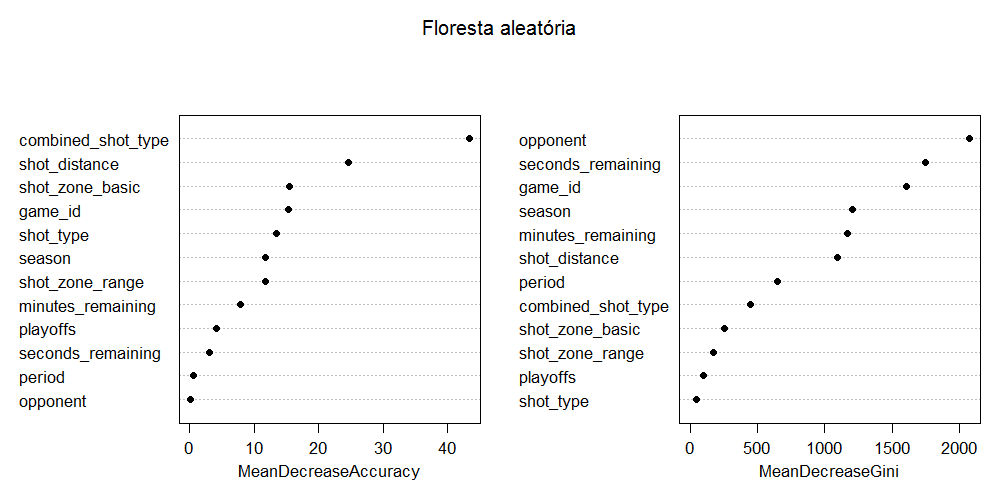

```r
varImpPlot(model_rf, main = "Floresta aleatória", pch = 19)
```

> A floresta se saiu bem na classificação dos arremessos não convertidos, com um erro de classificação de 1.5%. Já nos arremessos convertidos o erro de classificação obtido foi gigantesco, 90%!

Das duas medidas calculadas para representar a importância de cada variável na classificação, em geral, é difícil fazer afirmações. A variável que pra uma medida se mostra a mais importante, *opponent*, na outra medida é a menos importante

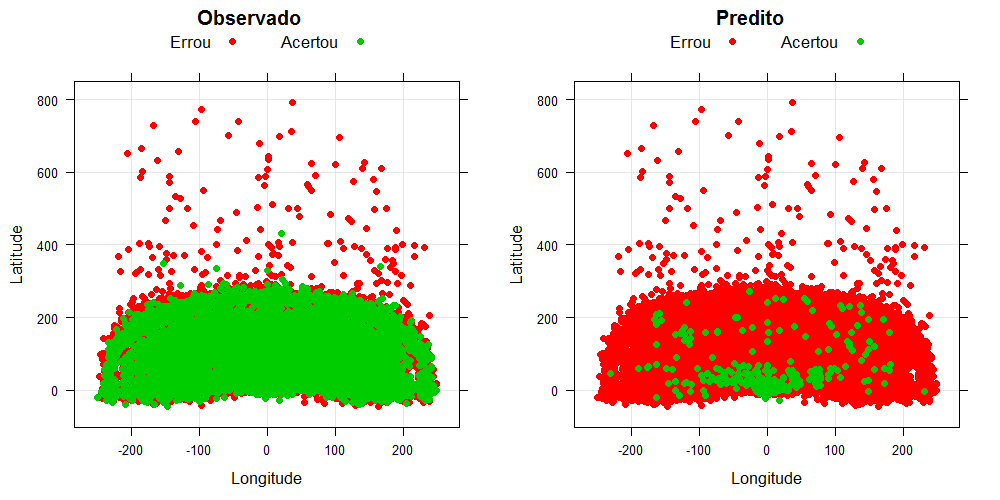

```r
print(xyplot(loc_y ~ loc_x
             , groups = shot_made_flag
             , col = 2:3
             , pch = 19
             , type = c("p", "g")
             , main = "Observado"
             , xlab = "Longitude"
             , ylab = "Latitude"
             , key = list(space = "top"
                          , text = list(c("Errou", "Acertou"))
                          , points = list(col = 2:3, pch = 19, cex = .8)
                          , columns = 2)
             , kobe_train)
      , position = c(0, 0, .5, 1), more = TRUE)

print(xyplot(loc_y ~ loc_x
             , groups = model_rf$predicted
             , col = 2:3
             , pch = 19
             , type = c("p", "g")
             , main = "Predito"
             , xlab = "Longitude"
             , ylab = "Latitude"
             , key = list(space = "top"
                          , text = list(c("Errou", "Acertou"))
                          , points = list(col = 2:3, pch = 19, cex = .8)
                          , columns = 2)
             , kobe_train)
      , position = c(.5, 0, 1, 1))
```

## Regressão logística

```r
model_glm <- glm(shot_made_flag
                 ~ combined_shot_type
                 + game_id
                 + minutes_remaining
                 + period
                 + playoffs
                 + season
                 + seconds_remaining
                 + shot_distance
                 + shot_type
                 + shot_zone_basic
                 + shot_zone_range
                 + opponent
                 , kobe_train
                 , family = binomial)

anova(model_glm, test = "Chisq")
```

```
Analysis of Deviance Table

Model: binomial, link: logit

Response: shot_made_flag

Terms added sequentially (first to last)

                   Df Deviance Resid. Df Resid. Dev  Pr(>Chi)
NULL                               25696      35325
combined_shot_type  5  1697.40     25691      33628 < 2.2e-16 ***
game_id             1     0.29     25690      33627 0.5917314
minutes_remaining   1    23.04     25689      33604 1.584e-06 ***
period              1    19.81     25688      33585 8.575e-06 ***
playoffs            1     2.91     25687      33582 0.0881328 .
season             19    50.02     25668      33532 0.0001303 ***
seconds_remaining   1    19.15     25667      33512 1.211e-05 ***
shot_distance       1   117.55     25666      33395 < 2.2e-16 ***
shot_type           1     6.67     25665      33388 0.0097822 **
shot_zone_basic     6    30.41     25659      33358 3.279e-05 ***
shot_zone_range     3    24.78     25656      33333 1.713e-05 ***
opponent           32    27.34     25624      33306 0.7013656
---
Signif. codes:  0 '***' 0.001 '**' 0.01 '*' 0.05 '.' 0.1 ' ' 1
```

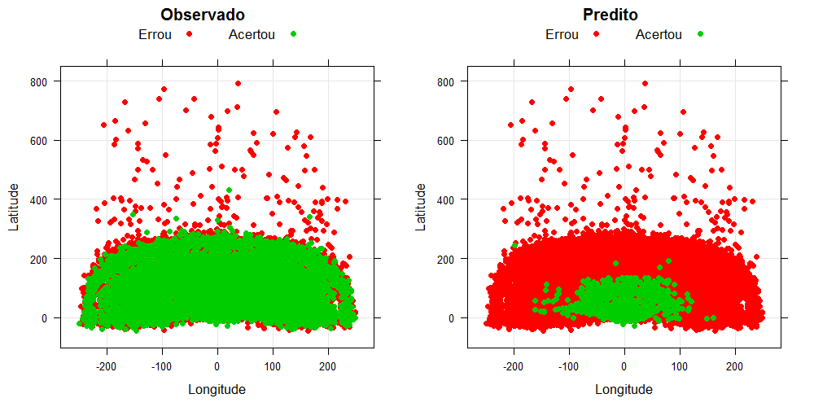

```r
print(xyplot(loc_y ~ loc_x
             , groups = shot_made_flag
             , type = c("p", "g")
             , pch = 19
             , col = 2:3
             , main = "Observado"
             , xlab = "Longitude"
             , ylab = "Latitude"
             , key = list(space = "top"
                          , text = list(c("Errou", "Acertou"))
                          , points = list(col = 2:3, pch = 19, cex = .8)
                          , columns = 2)
             , kobe_train)
      , position = c(0, 0, .5, 1)
      , more = TRUE)

print(xyplot(loc_y ~ loc_x
             , groups = ifelse(model_glm$fitted.values > .5, 1, 0)
             , type = c("p", "g")
             , pch = 19
             , col = 2:3
             , main = "Predito"
             , xlab = "Longitude"
             , ylab = "Latitude"
             , key = list(space = "top"
                          , text = list(c("Errou", "Acertou"))
                          , points = list(col = 2:3, pch = 19, cex = .8)
                          , columns = 2)
             , kobe_train)
      , position = c(.5, 0, 1, 1))
```

```r
mean(ifelse(model_glm$fitted.values > .5, 1, 0) != model_glm$y)
```

```
[1] 0.3861151
```

```r
table(model_glm$y, ifelse(model_glm$fitted.values > .5, 1, 0))
```

```
        0     1
  0 11980  2252
  1  7670  3795
```

> O erro de classificação dos arremessos errados é de 16% [ 2252 / (2252+11980) ], já o dos arremessos convertivos é de 67% [ 7670 / (3795+7670) ]

## Discriminante de Fischer

### Linear

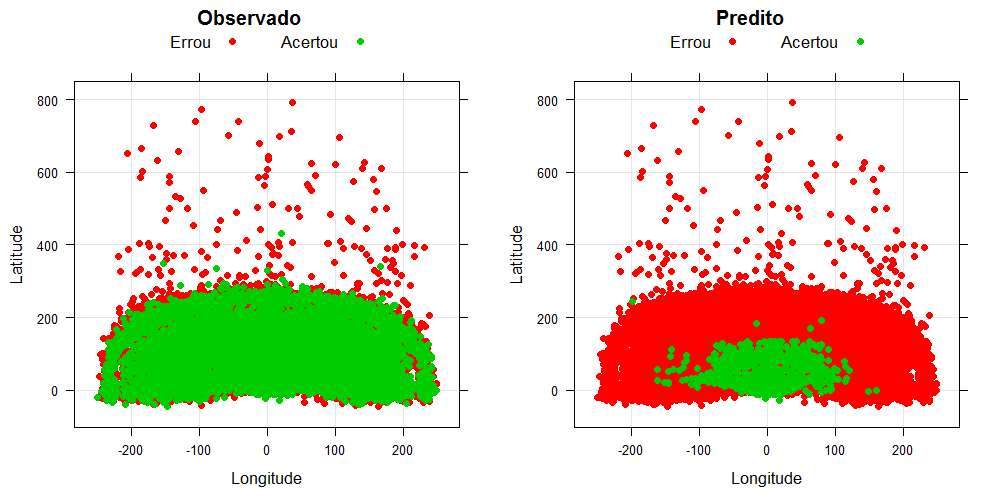

```r
library(MASS)

model_dfl <- lda(shot_made_flag
                 ~ combined_shot_type
                 + game_id
                 + minutes_remaining
                 + period
                 + playoffs
                 + season
                 + seconds_remaining
                 + shot_distance
                 + shot_type
                 + shot_zone_basic
                 + shot_zone_range
                 + opponent
                 , kobe_train)

pred_dfl <- predict(model_dfl, kobe_train)

print(xyplot(loc_y ~ loc_x
             , groups = shot_made_flag
             , type = c("p", "g")
             , pch = 19
             , col = 2:3
             , main = "Observado"
             , xlab = "Longitude"
             , ylab = "Latitude"
             , key = list(space = "top"
                          , text = list(c("Errou", "Acertou"))
                          , points = list(col = 2:3, pch = 19, cex = .8)
                          , columns = 2)
             , kobe_train)
      , position = c(0, 0, .5, 1)
      , more = TRUE)

print(xyplot(loc_y ~ loc_x
             , groups = pred_dfl$class
             , type = c("p", "g")
             , pch = 19
             , col = 2:3
             , main = "Predito"
             , xlab = "Longitude"
             , ylab = "Latitude"
             , key = list(space = "top"
                          , text = list(c("Errou", "Acertou"))
                          , points = list(col = 2:3, pch = 19, cex = .8)
                          , columns = 2)
             , kobe_train)
      , position = c(.5, 0, 1, 1))
```

```r
table(kobe_train$shot_made_flag, pred_dfl$class)
```

```
         no   yes
  no  11985  2247
  yes  7661  3804
```

> O erro de classificação dos arremessos errados é de 16% [ 2247 / (2247+11985) ], já o dos arremessos convertivos é de 67% [ 7661 / (3804 + 7661) ]

### Regularizado

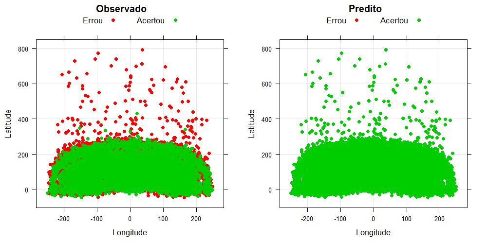

```r
library(klaR)

model_dfr <- rda(shot_made_flag
                 ~ combined_shot_type
                 + game_id
                 + minutes_remaining
                 + period
                 + playoffs
                 + season
                 + seconds_remaining
                 + shot_distance
                 + shot_type
                 + shot_zone_basic
                 + shot_zone_range
                 + opponent
                 , kobe_train)

pred_dfr <- predict(model_dfr, kobe_train)

print(xyplot(loc_y ~ loc_x
             , groups = shot_made_flag
             , type = c("p", "g")
             , pch = 19
             , col = 2:3
             , main = "Observado"
             , xlab = "Longitude"
             , ylab = "Latitude"
             , key = list(space = "top"
                          , text = list(c("Errou", "Acertou"))
                          , points = list(col = 2:3, pch = 19, cex = .8)
                          , columns = 2)
             , kobe_train)
      , position = c(0, 0, .5, 1)
      , more = TRUE)

print(xyplot(loc_y ~ loc_x
             , groups = pred_dfr$class
             , type = c("p", "g")
             , pch = 19
             , col = 2:3
             , main = "Predito"
             , xlab = "Longitude"
             , ylab = "Latitude"
             , key = list(space = "top"
                          , text = list(c("Errou", "Acertou"))
                          , points = list(col = 2:3, pch = 19, cex = .8)
                          , columns = 2)
             , kobe_train)
      , position = c(.5, 0, 1, 1))
```

```r
table(kobe_train$shot_made_flag, pred_dfr$class)
```

```
         no   yes
  no      0 14232
  yes     0 11465
```

> Aqui todos os arremessos foram classificados como convertidos

*Por problemas numéricos não foi possível utilizar o Discriminante de Fischer Quadrático*

# Predições, comparações e considerações

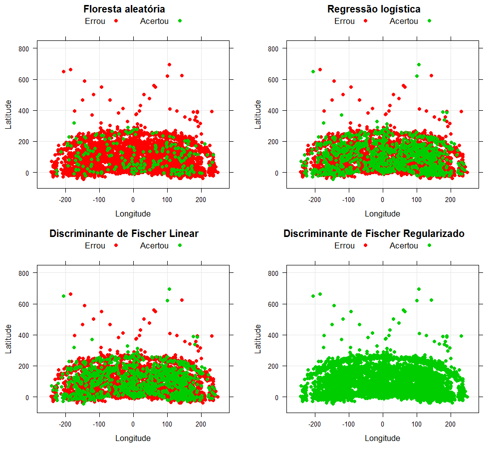

```r
print(xyplot(loc_y ~ loc_x
             , groups = predict(model_rf, kobe_test)
             , type = c("p", "g")
             , pch = 19
             , col = 2:3
             , main = "Floresta aleatória"
             , xlab = "Longitude"
             , ylab = "Latitude"
             , key = list(space = "top"
                          , text = list(c("Errou", "Acertou"))
                          , points = list(col = 2:3, pch = 19, cex = .8)
                          , columns = 2)
             , kobe_train)
      , position = c(0, .5, .5, 1)
      , more = TRUE)

print(xyplot(loc_y ~ loc_x
             , groups = ifelse(predict(model_glm, kobe_test, type = "response") > .5, 1, 0)
             , type = c("p", "g")
             , pch = 19
             , col = 2:3
             , main = "Regressão logística"
             , xlab = "Longitude"
             , ylab = "Latitude"
             , key = list(space = "top"
                          , text = list(c("Errou", "Acertou"))
                          , points = list(col = 2:3, pch = 19, cex = .8)
                          , columns = 2)
             , kobe_train)
      , position = c(.5, .5, 1, 1)
      , more = TRUE)

print(xyplot(loc_y ~ loc_x
             , groups = predict(model_dfl, kobe_test)$class
             , type = c("p", "g")
             , pch = 19
             , col = 2:3
             , main = "Discriminante de Fischer Linear"
             , xlab = "Longitude"
             , ylab = "Latitude"
             , key = list(space = "top"
                          , text = list(c("Errou", "Acertou"))
                          , points = list(col = 2:3, pch = 19, cex = .8)
                          , columns = 2)
             , kobe_train)
      , position = c(0, 0, .5, .5)
      , more = TRUE)

print(xyplot(loc_y ~ loc_x
             , groups = predict(model_dfr, kobe_test)$class
             , type = c("p", "g")
             , pch = 19
             , col = 2:3
             , main = "Discriminante de Fischer Regularizado"
             , xlab = "Longitude"
             , ylab = "Latitude"
             , key = list(space = "top"
                          , text = list(c("Errou", "Acertou"))
                          , points = list(col = 2:3, pch = 19, cex = .8)
                          , columns = 2)
             , kobe_train)
      , position = c(.5, 0, 1, .5))
```

> Nenhuma das metodologias utilizadas resultou em ótimas predições na base de treino. A Floresta Aleatória apresentou uma altíssima acurária na classificação dos aremessos errados e uma acurária baixíssima nos arremessos convertidos

> A Regressão Logística e o Discriminante de Fischer Linear apresentaram resultados praticamente idênticos e em comparação à Floresta Aleatória tiveram uma maior acurária para os arremessos convertidos e uma menor acurácia para os arremessos errados

> Como os resultados não foram bons na base de treino as classificações obtidas para a base de teste não são muito confiáveis

> O Discriminante de Fischer Regularizado continua classificando todos os arremessos como convertidos, e a Regressão Logística e o Discriminante de Fischer Linear continuam tendo resultados praticamente idênticos

> Essas más classficações podem simplesmente representar a dificuldade em predizer o resultado de um arremesso com base em covariáveis. Talvez o processo seja tão aleatório que uma predição razoável se torna inviável e impraticável.